# Class 5 Reproducible Research

## Assignment 1

This assignment makes use of data from a personal activity monitoring device. This device collects data at 5 minute intervals through out the day. The data consists of two months of data from an anonymous individual collected during the months of October and November, 2012 and include the number of steps taken in 5 minute intervals each day.

The variables included in this dataset are:

```
steps: Number of steps taking in a 5-minute interval (missing values are coded as NA)
date: The date on which the measurement was taken in YYYY-MM-DD format
interval: Identifier for the 5-minute interval in which measurement was taken
```

The dataset is stored in a comma-separated-value (CSV) file and there are a total of 17,568 observations in this dataset.

Submit:

1. Code for reading in the dataset and/or processing the data
2. Histogram of the total number of steps taken each day
3. Mean and median number of steps taken each day
4. Time series plot of the average number of steps taken
5. The 5-minute interval that, on average, contains the maximum number of steps
6. Code to describe and show a strategy for imputing missing data
7. Histogram of the total number of steps taken each day after missing values are imputed
8. Panel plot comparing the average number of steps taken per 5-minute interval across weekdays and weekends
9. All of the R code needed to reproduce the results (numbers, plots, etc.) in the report

### 1. Code for reading in the dataset and/or processing the data

#### Loading and preprocessing the data

```r
# Prepare the workspace
rm(list=ls())

# Set the working directory
setwd("C:/Users/star/Desktop/COURSERA/Class_5_Reproducible_Research_Project_1/Project_1")

# Load the raw data
activity_raw <- read.csv("activity.csv", stringsAsFactors=FALSE)

# Check the the internal structure of an R object
str(activity_raw)
```

```
## 'data.frame':    17568 obs. of  3 variables:
##  $ steps   : int  NA NA NA NA NA NA NA NA NA NA ...
##  $ date    : chr  "10/1/2012" "10/1/2012" "10/1/2012" "10/1/2012" ...
##  $ interval: int  0 5 10 15 20 25 30 35 40 45 ...
```

```r
# Transform the date character to a date format
activity_raw$date <- as.Date(activity_raw$date,format="%m/%d/%Y")
str(activity_raw)
```

```
## 'data.frame':    17568 obs. of  3 variables:
##  $ steps   : int  NA NA NA NA NA NA NA NA NA NA ...
##  $ date    : Date, format: "2012-10-01" "2012-10-01" ...
##  $ interval: int  0 5 10 15 20 25 30 35 40 45 ...
```

```r
head(activity_raw)
```

```
##   steps       date interval
## 1    NA 2012-10-01        0
## 2    NA 2012-10-01        5
## 3    NA 2012-10-01       10
## 4    NA 2012-10-01       15
## 5    NA 2012-10-01       20
## 6    NA 2012-10-01       25
```

```r
# Compute the weekdays
activity_raw<-data.frame(date=activity_raw$date, weekday=tolower(weekdays(activity_raw$date)), steps=activity_raw$steps,interval=activity_raw$interval)

head(activity_raw)
```

```
##         date weekday steps interval
## 1 2012-10-01  monday    NA        0
## 2 2012-10-01  monday    NA        5
## 3 2012-10-01  monday    NA       10
## 4 2012-10-01  monday    NA       15
## 5 2012-10-01  monday    NA       20
## 6 2012-10-01  monday    NA       25
```

```r
# Compute the day type (weekend or weekday)
activity_raw<-cbind(activity_raw, daytype=ifelse(activity_raw$weekday=="saturday" | activity_raw$weekday=="sunday", "weekend","weekday"))

head(activity_raw)
```

```
##         date weekday steps interval daytype
## 1 2012-10-01  monday    NA        0 weekday
## 2 2012-10-01  monday    NA        5 weekday
## 3 2012-10-01  monday    NA       10 weekday
## 4 2012-10-01  monday    NA       15 weekday
## 5 2012-10-01  monday    NA       20 weekday
## 6 2012-10-01  monday    NA       25 weekday
```

```r
# Combine into the final data.frame
activity<-data.frame(date=activity_raw$date, weekday=activity_raw$weekday, daytype=activity_raw$daytype, interval=activity_raw$interval, steps=activity_raw$steps)

head(activity)
```

```
##         date weekday daytype interval steps
## 1 2012-10-01  monday weekday        0    NA
## 2 2012-10-01  monday weekday        5    NA
## 3 2012-10-01  monday weekday       10    NA
## 4 2012-10-01  monday weekday       15    NA
## 5 2012-10-01  monday weekday       20    NA
## 6 2012-10-01  monday weekday       25    NA
```

```r
# Clear the workspace
rm(activity_raw)
```

### 2. Histogram of the total number of steps taken each day

```r
steps_per_day<-aggregate(steps ~ date, activity, sum)
head(steps_per_day)
```

```
##         date steps
## 1 2012-10-02   126
## 2 2012-10-03 11352
## 3 2012-10-04 12116
## 4 2012-10-05 13294
## 5 2012-10-06 15420
## 6 2012-10-07 11015
```

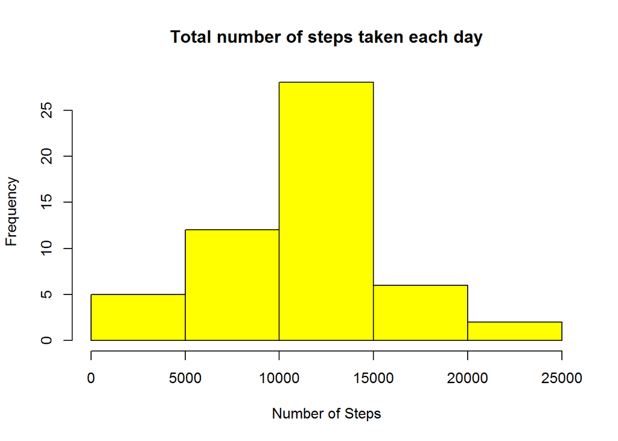

```r
hist(steps_per_day$steps, main = "Total number of steps taken each day", xlab = "Number of Steps", col = "yellow")
```